# Welcart全体構築｜ステップ割引 UI比較資料

PC画面の現行スクリーンショットと適用後の生成サンプル

Codex

Version 6

Session 01a07a74-c971-7aa1-a0b8-757dc32eeb87

Generated 20260907-163043

管理設定・カート・購入確認・受注編集を、画面ごとの独立したブロックで比較します。画像をクリックすると、新しいタブで原寸画像を開きます。

Draft・UI判断用 現行はPCで再撮影 適用後は生成案・未実装

## 1. 比較の前提

表示名を「ステップ割引」に統一しました。現行のカート・購入確認は、商品画像付きの2商品で再撮影しました。適用後のカート・購入確認の生成案も、同じ商品画像・数量・税区分に揃えています。

| 項目 | 現行スクリーンショット | 適用後の生成サンプル |
| --- | --- | --- |
| 取得・作成 | 2026-09-07、recommended環境A。カート・確認はCodex内ブラウザで再撮影、その他はChrome | 同日のPC画面を参照したCodex画像生成 |
| 撮影サイズ | カート・確認はviewport 1,356×693、本文幅960px（出力画像1,341×685）。受注画像1,440×800、管理設定画像1,585×715 | 画面ごとに独立した横長画像 |
| 版 | WordPress 7.0.4／PHP 8.3.33／Welcart 2.12.1 | 配置・表示の案。実装後の動作証拠ではない |
| 商品 | カート・確認は赤いマグ10,000円＋緑のボウル5,000円、各1個。既存受注は基準商品1個 | カート・確認は現行と同じ2商品・各1個。受注編集案は従来の基準商品で数量1→3 |
| 税区分・税率 | カート・確認は税別登録、10%、切捨て。既存受注は税込登録 | カート・確認は同じ税別登録、10%、切捨て。受注編集は従来の税込登録例 |
| 計算基準 | プラグイン未実装 | 減額前の登録販売価格×数量。税込・税抜は店舗の登録区分に従う |
| ティア | 未設定 | 全段を固定金額で統一。10,000円以上で500円、30,000円以上で3,000円、50,000円以上で5,000円（無効） |
| 送料・手数料・ポイント | すべて0 | すべて0 |
| 注文 | 確認画面で停止し未確定。受注画面は既存ダミー受注1000 | 架空の保存済み元注文と未保存の編集例 |

ユーザーの指定に基づき、ローカル環境AのWordPress追加CSSでカート・購入確認の本文幅を645pxから最大960pxへ広げて再撮影しました。両画面の商品表で幅960px・横のはみ出しなしを確認しています。テーマのソースファイルは変更していません。生成案はステップ割引を追加した配置の見本です。

## 2. 管理画面：参照元と新設ページ案

既存Welcart管理画面を見た目の参照元にして、新しい「ステップ割引」設定ページを示します。同一ページの変更前後ではありません。

**現行・基本設定** PC実画面

[figure not shown]

サイドメニュー、フォーム、保存操作の見た目を参照します。

**新設・ステップ割引** 生成案

[figure not shown]

有効・しきい値・方式・割引値を編集し、一覧全体を保存します。

| 要素 | 操作・文言の案 |
| --- | --- |
| 一覧 | 有効／しきい値（円）／方式／割引値／削除。保存後はしきい値昇順 |
| 行操作 | 「ティアを追加」「削除」。編集後に「変更を保存」 |
| 成功 | 「設定を保存しました。」 |
| 不正入力 | 「しきい値が重複しています。保存されていません。」旧設定を保持。成功通知と同時には表示しない |
| 基準の説明 | 「店舗の登録販売価格を基準に判定します。税込・税抜は店舗設定に従います。ポイントなどの減額前の金額が対象です。」 |
| 空一覧 | 割引なし。画像の3行は説明用で、初期値として配布しない |
| 操作確認 | label、キーボード、追加・削除後のフォーカス、行に関連付けたエラー |

## 3. 購入経路：画面ごとの比較

3-1・3-2・3-3で、現行画像とその画面専用の生成案を一組ずつ表示します。各ブロック内で金額と追加操作を確認できます。3-1・3-2は、現行・生成案とも画像付き2商品・各1個・税別登録の条件で比較します。

### 3-1 カート

既存の商品表に「ステップ割引」の行を追加し、適用条件を短く添えます。

3-1 カート

**現行** PC実画面

[figure not shown]

**適用後** 生成案

[figure not shown]

| 比較点 | 現行 | 適用後案 |
| --- | --- | --- |
| 商品合計（各画面の登録区分） | 15,000円（税別・2商品） | 15,000円（税別・2商品、減額前） |
| ステップ割引 | 行なし | −500円 |
| 適用条件 | 表示なし | 税別登録10,000円以上：500円引き |
| 操作後の確認 | 既存の数量更新・削除 | 再表示で累積せず、しきい値未満なら割引を解除 |

### 3-2 購入確認

割引額と適用条件を示し、購入者が確認する請求額へ反映します。

3-2 購入確認

**現行** PC実画面

[figure not shown]

**適用後** 生成案

[figure not shown]

| 比較点 | 現行 | 適用後案 |
| --- | --- | --- |
| 商品合計 | 15,000円（税別・2商品） | 15,000円（税別・2商品） |
| ステップ割引 | 0円 | −500円 |
| 消費税（10%・切捨て） | 外税1,500円 | 外税1,450円 |
| 総合計金額 | 16,500円 | 15,950円 |

確認後に設定が変わり、条件・割引結果・請求額が変化したら、新しい内容を再確認するまで注文を確定しません。画像の顧客欄はダミーで、比較対象は商品・金額欄です。

### 3-3 受注編集・元注文・変更履歴

注文時の全ティアから再計算し、未保存のプレビューと保存済み情報を区別します。

3-3 受注編集

**現行・既存ダミー受注1000** PC実画面

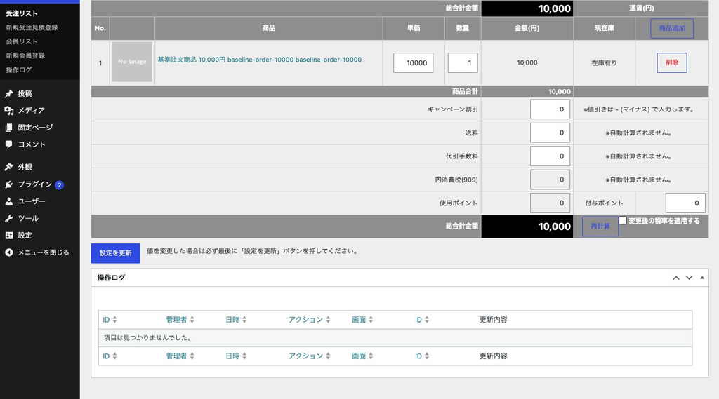

**適用後・数量1から3への編集** 生成案

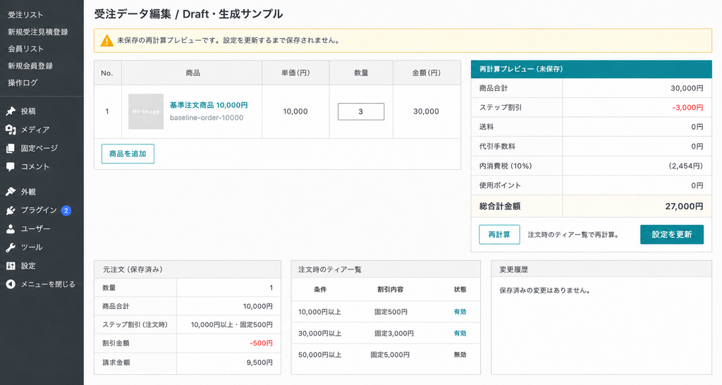

| 比較点 | 現行受注 | 生成案の元注文（保存済み） | 生成案の再計算（未保存） |
| --- | --- | --- | --- |
| 数量・商品合計 | 1個・10,000円 | 1個・10,000円 | 3個・30,000円 |
| 選ぶティア | なし | 10,000円以上・固定500円 | 30,000円以上・固定3,000円 |
| ステップ割引 | 0円 | 500円 | 3,000円 |
| 請求額 | 10,000円 | 9,500円 | 27,000円 |
| 内税 | 909円 | 863円 | 2,454円 |
| 履歴 | 既存の操作ログ | 元注文と当時の全ティアを保持 | プレビューでは履歴を追加せず、管理者の保存時に前後値・日時・管理者を記録 |

元注文のティア一覧は、適用した1段だけでなく無効行を含む一覧全体を保持します。数量を減らした場合も当時の下位ティアを選び、店舗の最新設定は使いません。

サンプルは全段を固定金額割引に揃えています。数量1→3で商品合計が10,000円→30,000円になり、割引が500円→3,000円へ切り替わる例です。

## 4. 引き渡しと確認状況

業務方針への回答は反映済みです。画面配置はDraftとして残し、金額の連携と保存結果は実装時に検証します。

| 状態 | 対象 | 次の確認 |
| --- | --- | --- |
| 反映済み | ステップ割引への名称変更、登録価格・減額前基準 | SSoTと詳細計画の表現を統一 |
| 反映済み | 破損時の注文停止と内部ログ、注文時一覧による受注編集・履歴 | 既存WordPress/Welcart経路での実装・TDD |
| 撮影済み | PC版の管理設定・カート・購入確認・受注金額欄 | 元画像と撮影条件を保持 |
| 草案 | 新設設定・購入経路・編集プレビューの配置 | 最終hook位置と照合 |
| 未検証 | 複数税率・標準ポイント・確定前変更・保存と履歴の整合 | 期待値を先に固定してTDDと実連携確認 |
| 未実施 | 実装後の画面 | 同じ商品・税・ポイント条件で撮影し生成案を実画面へ置き換える |

基にした資料はUI比較v5（旧版は本資料に含めていません）です。v6では3-1・3-2の適用後の生成案を、現行と同じ赤いマグと緑のボウル各1個・税別登録へ揃え、割引後の税額と請求額を更新しました。管理設定・受注編集の案と旧版は保持しています。

親フレーム: [Issue #3 v1](https://github.com/satokupo/welcart-tiered-discounts/issues/3)。追加の業務判断: [回答記録](https://github.com/satokupo/welcart-tiered-discounts/issues/3#issuecomment-5565656949)。詳細計画: [子Issue #4](https://github.com/satokupo/welcart-tiered-discounts/issues/4)。画像・Markdown・HTMLはローカルに残存し、commit・pushしていません。